# Position dimensions V2

Anonymous Authors

2026-09-17

```r
library(psych)
library(dplyr)
library(tidyr)
setwd(".")
```

```r
brands = read.csv("Updated_Brands_New.csv") %>%
  dplyr::select(-c("X", "X.1")) %>%
  mutate(
    VesselSmall = 6-VesselBig, #cruise1 reverse coded
    NotUrban=6-Urban, # jacket recoded
    Ritual = 6-Convenience, # coffee 2 recoded
    CruiseL_H = 6-(VesselSmall + Service + Conventional_Expedition + Family_AdultOnly)/4,
    jacketL_H = (Technical + NotUrban + Value)/3,
    catfoodL_H = (Science_Natural + Trad_UltPrem)/2,
    VetFocus = 6-Vet_General,
    BaristaInvolve = (Auto_Manual + Ritual)/2
         )
names(brands)
```

```
##  [1] "Key"                     "Brand"
##  [3] "Category"                "Vet_General"
##  [5] "Science_Natural"         "Trad_UltPrem"
##  [7] "VesselBig"               "Service"
##  [9] "Conventional_Expedition" "Family_AdultOnly"
## [11] "Technical"               "Urban"
## [13] "Value"                   "Sustainability"
## [15] "DrillDIY_pro"            "Auto_Manual"
## [17] "Convenience"             "Drip_Espresso"
## [19] "BuildGrade"              "VesselSmall"
## [21] "NotUrban"                "Ritual"
## [23] "CruiseL_H"               "jacketL_H"
## [25] "catfoodL_H"              "VetFocus"
## [27] "BaristaInvolve"
```

```r
describe(brands)
```

```
##                         vars   n   mean    sd median trimmed    mad  min    max
## Key*                       1 276 138.50 79.82 138.50  138.50 102.30 1.00 276.00
## Brand*                     2 276 136.71 79.49 136.50  136.52 102.30 1.00 274.00
## Category*                  3 276   2.95  1.31   3.00    2.94   1.48 1.00   5.00
## Vet_General                4  27   4.48  0.80   4.67    4.66   0.25 1.92   5.00
## Science_Natural            5  27   3.13  1.62   4.00    3.15   1.48 1.00   5.00
## Trad_UltPrem               6  27   2.86  1.27   2.92    2.83   1.36 1.00   5.00
## VesselBig                  7  25   2.58  1.44   2.17    2.51   1.73 1.00   5.00
## Service                    8  25   3.33  1.26   3.50    3.38   1.11 1.00   5.00
## Conventional_Expedition    9  25   2.30  1.12   2.17    2.19   1.24 1.00   5.00
## Family_AdultOnly          10  25   3.46  1.23   4.00    3.53   0.62 1.00   5.00
## Technical                 11  21   3.23  1.27   3.33    3.25   1.61 1.17   5.00
## Urban                     12  21   2.74  1.08   2.67    2.74   1.36 1.08   4.42
## Value                     13  21   3.24  0.92   3.25    3.25   0.74 1.50   5.00
## Sustainability            14  21   3.32  0.77   3.42    3.29   0.86 2.17   5.00
## DrillDIY_pro              15  19   3.33  1.49   3.33    3.37   2.22 1.00   5.00
## Auto_Manual               16  23   2.01  1.09   1.75    1.85   0.62 1.00   5.00
## Convenience               17  23   3.67  0.97   4.00    3.75   0.86 1.17   5.00
## Drip_Espresso             18  23   2.43  1.64   1.33    2.31   0.49 1.00   5.00
## BuildGrade                19  23   2.57  1.18   2.50    2.51   1.24 1.00   5.00
## VesselSmall               20  25   3.42  1.44   3.83    3.49   1.73 1.00   5.00
## NotUrban                  21  21   3.26  1.08   3.33    3.26   1.36 1.58   4.92
## Ritual                    22  23   2.33  0.97   2.00    2.25   0.86 1.00   4.83
## CruiseL_H                 23  25   2.87  1.14   2.29    2.82   1.02 1.46   4.81
## jacketL_H                 24  21   3.24  1.01   3.31    3.25   1.40 1.67   4.69
## catfoodL_H                25  27   3.00  1.39   3.08    2.98   1.98 1.17   5.00
## VetFocus                  26  27   1.52  0.80   1.33    1.34   0.25 1.00   4.08
## BaristaInvolve            27  23   2.17  1.02   2.00    2.05   0.68 1.00   4.92
##                          range  skew kurtosis   se
## Key*                    275.00  0.00    -1.21 4.80
## Brand*                  273.00  0.01    -1.22 4.78
## Category*                 4.00  0.24    -0.95 0.08
## Vet_General               3.08 -2.34     4.53 0.15
## Science_Natural           4.00 -0.07    -1.95 0.31
## Trad_UltPrem              4.00  0.06    -1.24 0.24
## VesselBig                 4.00  0.25    -1.58 0.29
## Service                   4.00 -0.37    -1.07 0.25
## Conventional_Expedition   4.00  0.57    -0.46 0.22
## Family_AdultOnly          4.00 -0.83    -0.84 0.25
## Technical                 3.83 -0.06    -1.49 0.28
## Urban                     3.33 -0.02    -1.52 0.24
## Value                     3.50 -0.04    -0.96 0.20
## Sustainability            2.83  0.19    -0.90 0.17
## DrillDIY_pro              4.00 -0.20    -1.62 0.34
## Auto_Manual               4.00  1.34     0.82 0.23
## Convenience               3.83 -0.78     0.07 0.20
## Drip_Espresso             4.00  0.61    -1.51 0.34
## BuildGrade                4.00  0.32    -0.96 0.25
## VesselSmall               4.00 -0.25    -1.58 0.29
## NotUrban                  3.33  0.02    -1.52 0.24
## Ritual                    3.83  0.78     0.07 0.20
## CruiseL_H                 3.35  0.53    -1.30 0.23
## jacketL_H                 3.03 -0.05    -1.48 0.22
## catfoodL_H                3.83  0.03    -1.75 0.27
## VetFocus                  3.08  2.34     4.53 0.15
## BaristaInvolve            3.92  1.12     0.55 0.21
```

# Cat food

- Vet to general
  - 1 — Veterinary/Therapeutic. The brand is strongly positioned around veterinary or clinically oriented nutrition for managing diagnosed health conditions, with therapeutic or veterinary-exclusive diets forming an important part of its identity.
  - 3 — Health/Nutrition Oriented. The brand emphasizes nutritional science or specific health benefits but primarily provides over-the-counter foods for generally healthy cats rather than therapeutic management of diagnosed conditions.
  - 5 — General Wellness/Lifestyle. The brand is primarily positioned around everyday feeding, taste, ingredients, lifestyle, naturalness, convenience, or general wellness rather than veterinary or therapeutic nutrition. General/Non-Therapeutic Nutrition.
- Science diet to natural
  - Science-Formulated (Nutrient-First): These brands focus strictly on nutrients (proteins, amino acids, vitamins) rather than how appealing the ingredients look to human eyes. They heavily utilize meat by-products, grains, and corn gluten meal because they are highly bioavailable, chemically consistent, and easily enriched with essential synthetic taurine. Examples: Purina ONE, Hill’s Science Diet, and Iams.
  - “Humanized” / Ancestral / Fresh (Ingredient-First): These brands market heavily to the owner’s emotions and dietary trends. They emphasize “real meat as the first ingredient,” grain-free formulations, raw-freeze-dried bits, and the total exclusion of artificial preservatives or by-products. The food looks and sounds like human meals (e.g., “Salmon and Sweet Potato Stew”).
- Traditional mass market to ultra premium
  - Traditional / Mass-Market Baseline: Dominated by highly processed, ambient dry kibble and budget-friendly grocery store canned pates. The focus is on long shelf-life, bulk affordability, and high palatability (adding fats and flavor coatings so cats find it addictive). Examples: Friskies, 9Lives, and private label supermarket brands.
  - Ultra-Premium Specialized: Focuses on high-moisture formats (pouch broths, minced cuts in gravies, human-grade shreds) or freeze-dried raw food that mimics an obligate carnivore’s natural prey diet. They command luxury pricing and are sold mostly through boutique pet stores or direct subscriptions.

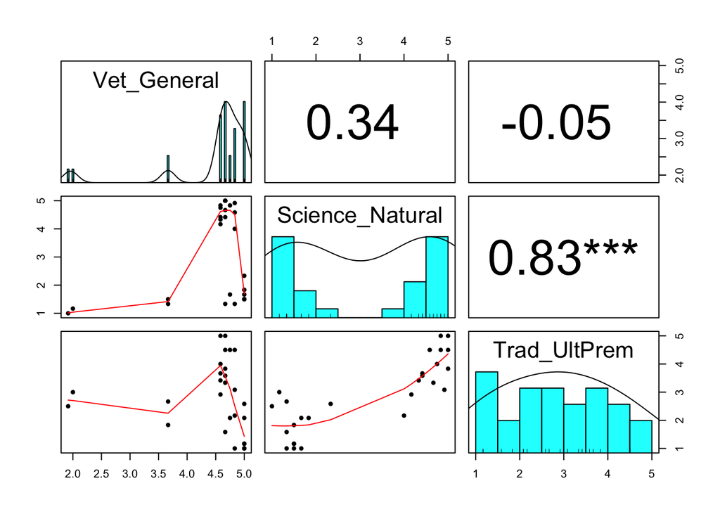

```r
catfood = c("Vet_General", "Science_Natural", "Trad_UltPrem")
pairs.panels(brands[, catfood], stars=T, ellipses = F)
```

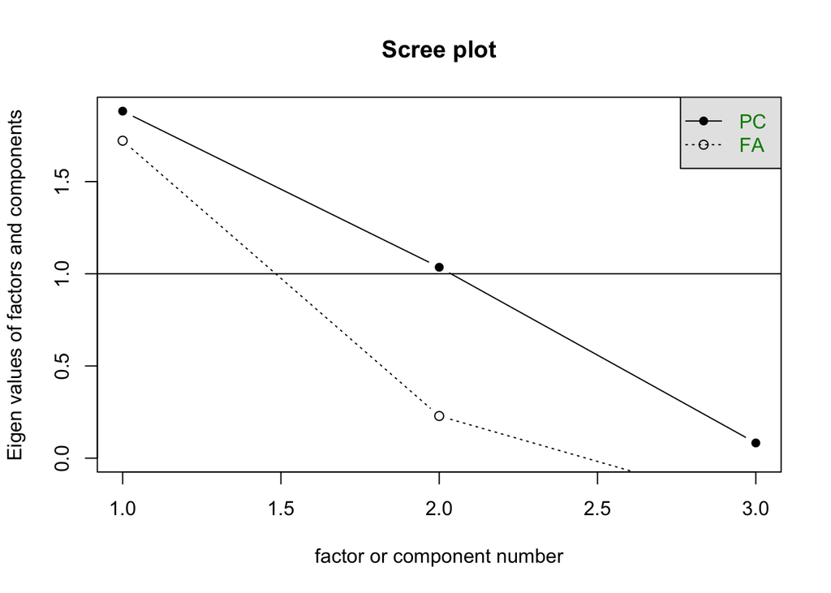

```r
scree(brands[, catfood])
```

```r
principal(brands[, catfood], rotate="promax", nfactor=2)
```

```
## Principal Components Analysis
## Call: principal(r = brands[, catfood], nfactors = 2, rotate = "promax")
## Standardized loadings (pattern matrix) based upon correlation matrix
##                   RC1   RC2   h2     u2 com
## Vet_General     -0.02  1.00 0.99 0.0073 1.0
## Science_Natural  0.91  0.23 0.96 0.0403 1.1
## Trad_UltPrem     0.99 -0.21 0.97 0.0348 1.1
##
##                        RC1  RC2
## SS loadings           1.82 1.09
## Proportion Var        0.61 0.36
## Cumulative Var        0.61 0.97
## Proportion Explained  0.63 0.37
## Cumulative Proportion 0.63 1.00
##
##  With component correlations of
##      RC1  RC2
## RC1 1.00 0.16
## RC2 0.16 1.00
##
## Mean item complexity =  1.1
## Test of the hypothesis that 2 components are sufficient.
##
## The root mean square of the residuals (RMSR) is  0.03
##  with the empirical chi square  1.07  with prob <  NA
##
## Fit based upon off diagonal values = 1
```

- I see two clusters: natural/ultra premium and traditional/Science. There is variation within each cluster.
- Most are general, but two are very much Vet and two are moderate on Vet. I’d say that Vet is a niche. I guess this could be interesting to probe
- I’m inclined to have a scale with Science_Natural combined with Trad_UltPrem. Keep Vet separate
- **Cat Food Tier (catfoodL_H):** Positions cat-food brands from mainstream, widely available, conventional/science-oriented offerings toward higher-priced, specialty, natural and ingredient-focused offerings.
- **Veterinary Focus (VetFocus):** Captures the extent to which a cat-food brand specializes in therapeutic diets designed to manage diagnosed health conditions under veterinary guidance.

# Boat cruise

- Vessel Big
  - Low (Small Ships / Yachts / River Boats): Capacity of 50 to 500 guests. Specific Attributes: Highly intimate atmosphere, short or non-existent lines, direct proximity to the water line, and the ability to slide into small, shallow bays, historic river channels, or private islands where mega-ships cannot physically fit. [1, 2, 3]
  - High (Mega Ships / Floating Resorts): Capacity of 3,500 to 7,500+ guests. Specific Attributes: Massive engineering marvels. They feature neighborhood-style floorplans, multi-story open atriums, extensive water parks, roller coasters, theaters, and dozens of distinct bars and restaurants.
- Service high
  - Low (Mass-Market Density): Staff-to-guest ratio around 1:3 or 1:4; tight space ratios. Specific Attributes: Crowded pool decks, a need to reserve theater seating or dining times weeks in advance, standard cabin sizes, and highly structured, buffet-oriented dining operations.
  - High (Ultra-Luxury Decadence): Staff-to-guest ratio approaching 1:1; massive space-per-guest metrics. Specific Attributes: Free-flowing, open-seating gourmet dining with no reservations required. Living spaces are exclusively multi-room suites with private verandas and dedicated personal butler service.
- Conventional to expedition
  - 1 — Conventional Leisure Cruising. Primarily visits established tourist ports using fixed itineraries and conventional shore excursions; the cruise experience relies substantially on leisure activities aboard the vessel and conventional tourism ashore.
  - 3 — Destination-Focused Exploration. Destinations and cultural or natural experiences are central to the cruise experience, including smaller or less conventional ports and substantial enrichment or immersion, but itineraries generally rely on established ports and conventional shore access.
  - 5 — Expedition/Basecamp Exploration. The vessel functions as a platform for active exploration of remote environments. Flexible itineraries, expedition teams, small-craft or Zodiac landings, wildlife/nature observation, and access to locations lacking conventional port infrastructure are central to the experience.
- Family friendly to adults only
  - 1 — Strongly Family/Multigenerational. The brand explicitly targets families traveling with children and provides substantial child/family-specific programming, facilities, entertainment, and accommodations. Disney
  - 3 — General Adult/Multigenerational. The brand welcomes families but neither families with children nor adults seeking a child-free/adult-oriented environment are central to its positioning.
  - 5 — Adults-Only/Strongly Adult-Oriented. The brand either restricts children or is explicitly designed and positioned around an adult experience, with little or no child-oriented programming and an emphasis on adult-oriented atmosphere and activities. Virgin/Viking .

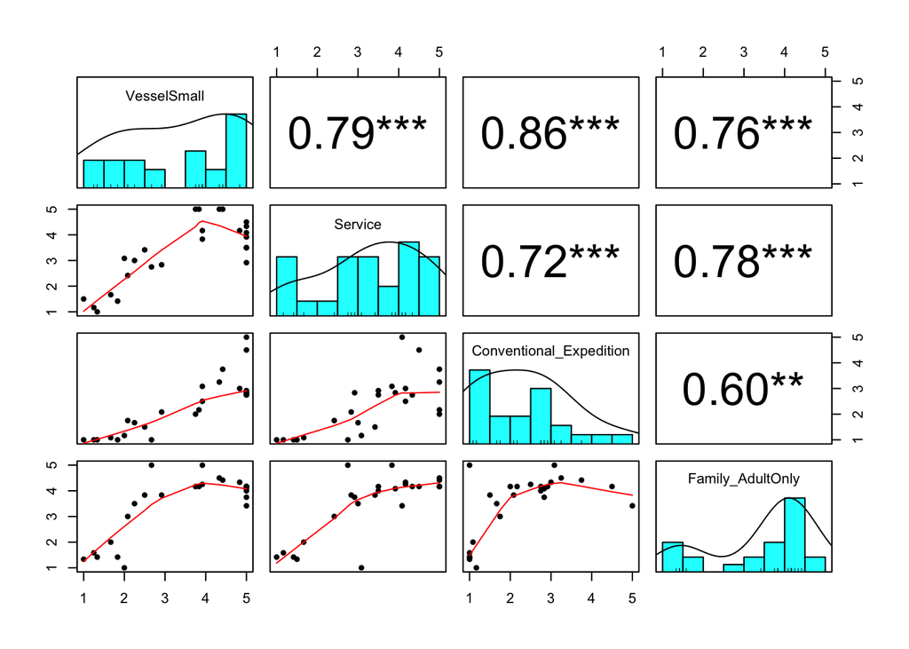

```r
cruise = c("VesselSmall", "Service", "Conventional_Expedition", "Family_AdultOnly")
pairs.panels(brands[, cruise], stars=T, ellipses = F)
```

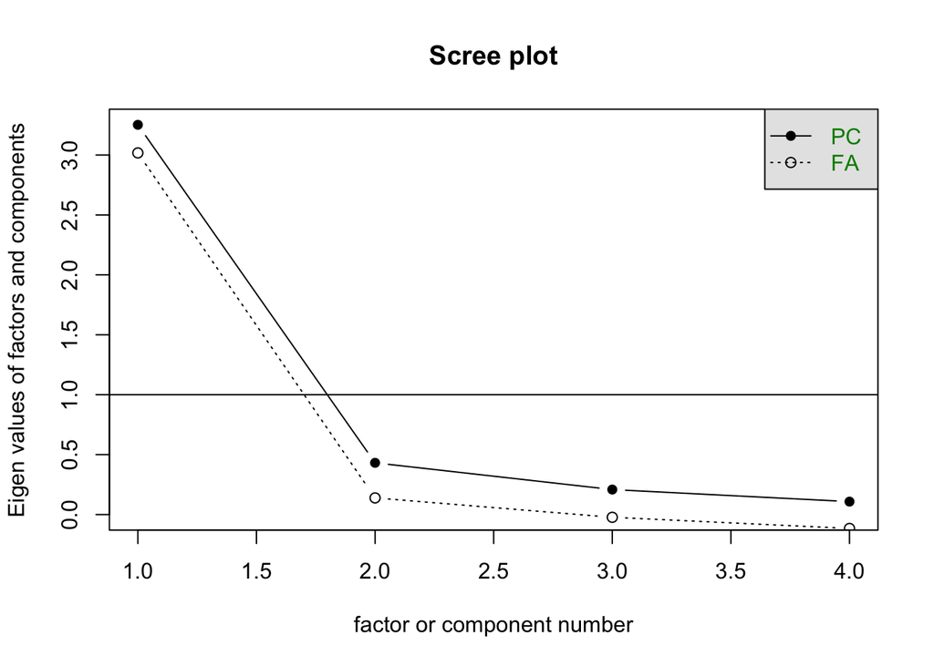

```r
scree(brands[, cruise])
```

```r
principal(brands[, cruise], rotate="promax", nfactor=2)
```

```
## Principal Components Analysis
## Call: principal(r = brands[, cruise], nfactors = 2, rotate = "promax")
## Standardized loadings (pattern matrix) based upon correlation matrix
##                           RC1   RC2   h2    u2 com
## VesselSmall              0.72  0.29 0.92 0.080 1.3
## Service                  0.27  0.71 0.86 0.142 1.3
## Conventional_Expedition  1.07 -0.13 0.96 0.036 1.0
## Family_AdultOnly        -0.13  1.06 0.94 0.058 1.0
##
##                        RC1  RC2
## SS loadings           1.85 1.83
## Proportion Var        0.46 0.46
## Cumulative Var        0.46 0.92
## Proportion Explained  0.50 0.50
## Cumulative Proportion 0.50 1.00
##
##  With component correlations of
##      RC1  RC2
## RC1 1.00 0.73
## RC2 0.73 1.00
##
## Mean item complexity =  1.2
## Test of the hypothesis that 2 components are sufficient.
##
## The root mean square of the residuals (RMSR) is  0.04
##  with the empirical chi square  6.57  with prob <  NA
##
## Fit based upon off diagonal values = 1
```

```r
psych::alpha(brands[, cruise])
```

```
## Number of categories should be increased  in order to count frequencies.
```

```
##
## Reliability analysis
## Call: psych::alpha(x = brands[, cruise])
##
##   raw_alpha std.alpha G6(smc) average_r S/N    ase mean  sd median_r
##       0.92      0.92    0.92      0.75  12 0.0075  3.1 1.1     0.77
##
##     95% confidence boundaries
##          lower alpha upper
## Feldt     0.91  0.92  0.94
## Duhachek  0.91  0.92  0.94
##
##  Reliability if an item is dropped:
##                         raw_alpha std.alpha G6(smc) average_r  S/N alpha se
## VesselSmall                  0.87      0.87    0.84      0.70  6.9   0.0131
## Service                      0.89      0.89    0.89      0.74  8.4   0.0108
## Conventional_Expedition      0.91      0.91    0.87      0.77 10.3   0.0093
## Family_AdultOnly             0.91      0.92    0.89      0.79 11.2   0.0085
##                           var.r med.r
## VesselSmall             0.00828  0.72
## Service                 0.01719  0.76
## Conventional_Expedition 0.00034  0.78
## Family_AdultOnly        0.00502  0.79
##
##  Item statistics
##                          n raw.r std.r r.cor r.drop mean  sd
## VesselSmall             25  0.95  0.94  0.94   0.89  3.4 1.4
## Service                 25  0.91  0.91  0.87   0.84  3.3 1.3
## Conventional_Expedition 25  0.88  0.88  0.85   0.79  2.3 1.1
## Family_AdultOnly        25  0.87  0.87  0.81   0.77  3.5 1.2
```

- Probably a single dimension with alpha=.92 and $\lambda_2\ll 1$
- Pushing it to two factors, big goes with conventional, service goes with adult only. The factors are highly correlated, so probably not a good idea.
- Clustering could be interesting, but not now.
- **Cruise positioning (CruseL_H):** Positions cruise lines from large, mainstream, family-oriented resort cruising with conventional ports toward smaller, more intimate, service-intensive, adult-oriented, exploration-focused cruising.